# Miniproject Apr 11

# Miniproject

For each of the following steps, let’s make sure we understand what “objects” we’re passing through to each step. Note: this miniproject is more about writing code, rather than good data analysis practices per se.

Data is from https://www.kaggle.com/costalaether/yeast-transcriptomics

## Preliminaries

Set working directory and read in CSV file.

```r
setwd("D:/XX_CodingClub/Day_09_Miniproject/")
```

```
The working directory was changed to D:/XX_CodingClub/Day_09_Miniproject inside a notebook chunk. The working directory will be reset when the chunk is finished running. Use the knitr root.dir option in the setup chunk to change the the working directory for notebook chunks.
```

```r
raw_data_table <- read.csv("yeast-transcriptomics/SC_expression.csv")
```

Inspect the data.

|  | X | IFFABF | SAASCC | IFFAFF | IFFAFA | INICIA | INICIF | SAABQI | FFNAAA | IFAAAR | AFIINC | IFFABN | SAARRS | FFNARN | SAABQR | FFNAAR | FAFASB | SAABBN | SAASCF | INICIQ | SAABFA | IFFAFQ | SAABRQ | IFFAFB | INICIA.1 | QCFQIA | FFNAAC | QNCSCN | SAABQQ | … |
| --- | --- | --- | --- | --- | --- | --- | --- | --- | --- | --- | --- | --- | --- | --- | --- | --- | --- | --- | --- | --- | --- | --- | --- | --- | --- | --- | --- | --- | --- | --- |
| 1 | YAL008W | 70.8049308 | 30.970186 | 118.3846533 | 110.7039503 | 74.10224 | 89.80222 | 7.3415361 | 112.09117 | 5.9736681 | 1.5999440 | 80.906634 | 25.248508 | 92.87835 | 14.3453666 | 97.81174 | 9.706003 | 11.5621808 | 53.7957089 | 87.287511 | 7.1145370 | 123.6629036 | 10.232139 | 100.5829827 | 148.0641808 | 7.210451 | 103.392926 | 25.230781 | 11.3035156 | … |
| 2 | YBR255W | 36.3687858 | 16.860290 | 27.7264519 | 34.5279281 | 35.44020 | 56.97130 | 15.4521855 | 26.85875 | 5.3840882 | 3.2055216 | 35.588256 | 18.951094 | 20.78055 | 19.8577066 | 26.51142 | 10.002635 | 14.0147646 | 23.5684783 | 47.303048 | 12.5800091 | 32.2781138 | 14.944556 | 32.7070538 | 37.2228387 | 13.255577 | 27.390313 | 24.827382 | 14.4192283 | … |
| 3 | YGR164W | 0.3513892 | 0.904239 | 0.4560272 | 0.2926096 | 0.00000 | 1.10356 | 0.7691133 | 18.08554 | 0.7119455 | 0.6140630 | 0.399868 | 3.747059 | 16.48786 | 0.4648961 | 21.62535 | 1.101011 | 0.9009491 | 0.8542478 | 1.249514 | 0.7067421 | 0.5589284 | 3.961434 | 0.3516888 | 0.3308697 | 2.840481 | 3.524759 | 4.327372 | 0.7245843 | … |
| 4 | YGR131W | 7.3791739 | 5.858715 | 12.1303227 | 12.6797476 | 11.27643 | 18.48464 | 2.3772593 | 22.25159 | 4.4051630 | 0.4675893 | 10.263280 | 12.300555 | 14.73175 | 4.2172721 | 19.09184 | 1.095667 | 1.5015819 | 9.5719563 | 22.937516 | 0.9423228 | 13.1348169 | 4.505896 | 9.6128259 | 546.9275773 | 2.348859 | 18.431551 | 4.877462 | 2.8983373 | … |
| 5 | YNL003C | 82.0493864 | 78.480411 | 67.2184048 | 64.1790302 | 75.71315 | 75.31799 | 20.1367847 | 43.32689 | 30.3244305 | 3.6505765 | 84.638736 | 120.082451 | 38.53671 | 20.5550508 | 48.86063 | 10.529089 | 15.2660828 | 126.0782168 | 95.498606 | 12.5800091 | 67.9097979 | 105.325323 | 67.4070106 | 60.5491510 | 17.133926 | 47.143649 | 43.933831 | 15.5061048 | … |
| 6 | YBR135W | 45.0656694 | 21.004719 | 53.8112060 | 42.9160688 | 17.72010 | 14.76012 | 13.4944425 | 21.76147 | 6.7746068 | 2.4280840 | 35.055098 | 17.715153 | 12.87809 | 12.4857821 | 22.98259 | 12.103108 | 14.0147646 | 24.3789186 | 10.977877 | 9.3289955 | 44.9937344 | 13.236070 | 38.8029922 | 8.2717419 | 18.372084 | 27.684043 | 39.533113 | 9.7094301 | … |

Looks like we have gene names and a bunch column labels. If we take a look at conditions_annotations.csv, we see that the different labels correspond to different experiments. Note: these data are generated from different labs with different conditions etc., but for the sake of this miniproject, we’re going to pretend we can compare data directly.

Ok, let’s take compare two experiments. AFIQCI corresponds to a WT experiment, AFNCCR corresponds to a swr1 mutant. We can use the $ operator to slice out the columns by their name.

```r
data_table <- data.frame(raw_data_table$X, raw_data_table$AFIQCI, raw_data_table$AFNCCR)
head(data_table)
```

|  | raw_data_table.X | raw_data_table.AFIQCI | raw_data_table.AFNCCR |
| --- | --- | --- | --- |
| 1 | YAL008W | 1.5778249 | 1.6045494 |
| 2 | YBR255W | 2.7106923 | 3.4161373 |
| 3 | YGR164W | 0.5432304 | 0.6314678 |
| 4 | YGR131W | 0.4012807 | 0.4934421 |
| 5 | YNL003C | 3.7835040 | 4.6790730 |
| 6 | YBR135W | 2.5196062 | 3.9544378 |

The colnames are hard to read, so let’s rename the column names.

```r
colnames(data_table) <- c("Gene", "WT", "swr1")
head(data_table)
```

|  | Gene | WT | swr1 |
| --- | --- | --- | --- |
| 1 | YAL008W | 1.5778249 | 1.6045494 |
| 2 | YBR255W | 2.7106923 | 3.4161373 |
| 3 | YGR164W | 0.5432304 | 0.6314678 |
| 4 | YGR131W | 0.4012807 | 0.4934421 |
| 5 | YNL003C | 3.7835040 | 4.6790730 |
| 6 | YBR135W | 2.5196062 | 3.9544378 |

Ok let’s take a look at some quick summary statistics. Looks like we might not have a very well distributed data set.

```r
summary(data_table$WT)
```

```
    Min.  1st Qu.   Median     Mean  3rd Qu.     Max.
     0.0      1.2      3.3    164.7      8.5 895800.0
```

```r
summary(data_table$swr1)
```

```
    Min.  1st Qu.   Median     Mean  3rd Qu.     Max.
     0.0      1.6      4.7    164.7     12.1 860200.0
```

Let’s plot WT vs swr1 on x and y to see.

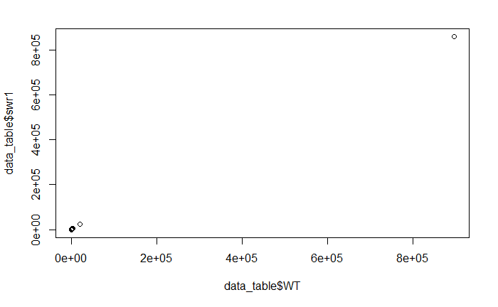

Looks like there might be a massive outlier. Let’s restrict the range to see more variation bottom left region.

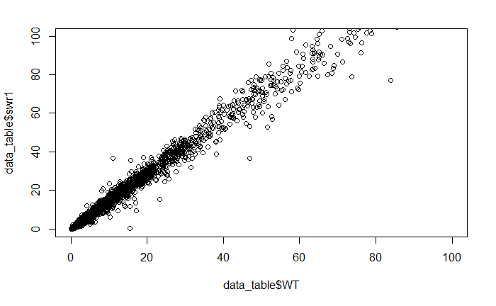

```r
plot(data_table$WT, data_table$swr1, xlim=c(0,100), ylim=c(0,100))
```

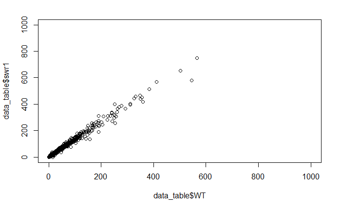

```r
plot(data_table$WT, data_table$swr1, xlim=c(0,1000), ylim=c(0,1000))
```

How many values to we lose when we restrict the view like this?

```r
str(data_table)
```

```
'data.frame':   6071 obs. of  3 variables:
 $ Gene: Factor w/ 6071 levels "__alignment_not_unique",..: 67 520 2323 2290 4619 400 425 3012 3070 5778 ...
 $ WT  : num  1.578 2.711 0.543 0.401 3.784 ...
 $ swr1: num  1.605 3.416 0.631 0.493 4.679 ...
```

```r
sum(data_table$WT >= 100)
```

```
[1] 123
```

```r
sum(data_table$swr1 >= 100)
```

```
[1] 183
```

```r
sum(data_table$WT >= 1000)
```

```
[1] 10
```

```r
sum(data_table$swr1 >= 1000)
```

```
[1] 12
```

So either of these views we’re still getting most of the data.

Since we’re here to compare change between the two conditions, let’s make a new column doing just that. We’ll also log2 it, so that decreases become negatives, and increases become positives.

```r
data_table$Ratio <- log2(data_table$swr1/data_table$WT)
head(data_table)
```

|  | Gene | WT | swr1 | Ratio |
| --- | --- | --- | --- | --- |
| 1 | YAL008W | 1.5778249 | 1.6045494 | 0.02423106 |
| 2 | YBR255W | 2.7106923 | 3.4161373 | 0.33370464 |
| 3 | YGR164W | 0.5432304 | 0.6314678 | 0.21714505 |
| 4 | YGR131W | 0.4012807 | 0.4934421 | 0.29826882 |
| 5 | YNL003C | 3.7835040 | 4.6790730 | 0.30649975 |
| 6 | YBR135W | 2.5196062 | 3.9544378 | 0.65027432 |

```r
data_table_sorted <- data_table[order(data_table$Ratio),]
head(data_table_sorted)
```

|  | Gene | WT | swr1 | Ratio |
| --- | --- | --- | --- | --- |
| 307 | SCER_lnc0054 | 0.002729801 | 0 | -Inf |
| 401 | YLL030C | 0.005459602 | 0 | -Inf |
| 794 | YDL246C | 0.008189403 | 0 | -Inf |
| 815 | YDR290W | 0.010919203 | 0 | -Inf |
| 840 | YLR461W | 0.008189403 | 0 | -Inf |
| 1040 | YAR070C | 0.010919203 | 0 | -Inf |

```r
tail(data_table_sorted)
```

|  | Gene | WT | swr1 | Ratio |
| --- | --- | --- | --- | --- |
| 5839 | SCER_lnc0217 | 0 | 0 | NaN |
| 5906 | YCR040W | 0 | 0 | NaN |
| 5913 | YGL177W | 0 | 0 | NaN |
| 5920 | YHL049C | 0 | 0 | NaN |
| 5927 | YNL339C | 0 | 0 | NaN |
| 6032 | YLR036C | 0 | 0 | NaN |

Uh oh. Looks like we get some weird values when either or both of the genes have 0 expression. Let’s split up the data table into well behaved and not so well behaved subsets to see what’s going on. We’ll create a logical vector to find where WT or swr1 are == 0. The single pipe | operator is a vectorized inclusive OR. Because R coerces TRUE to 1 and FALSE to 0 when you try to add them, we can sum() to see how many abnormals we have

```r
abnormals <- data_table_sorted$WT == 0 | data_table_sorted$swr1 == 0
sum(abnormals)
```

```
[1] 209
```

Now let’s use this logical vector to split off our data set. We’ll use ! to get the normal genes.

```r
data_table_sorted_abnormal <- data_table_sorted[abnormals,]
data_table_sorted_normal <- data_table_sorted[!abnormals,]
```

Let’s take a look at our normal data set now

```r
head(data_table_sorted_normal, n=10)
```

|  | Gene | WT | swr1 | Ratio |
| --- | --- | --- | --- | --- |
| 3934 | YDR334W | 15.49980933 | 0.075914163 | -7.673666 |
| 1332 | SCER_lnc0435 | 0.03821721 | 0.003450644 | -3.469285 |
| 2589 | YKL178C | 0.29208869 | 0.037957082 | -2.943966 |
| 3131 | YFL059W | 0.17743706 | 0.024154506 | -2.876943 |
| 4436 | YAR075W | 0.02456821 | 0.003450644 | -2.831855 |
| 5733 | YHR185C | 0.02456821 | 0.003450644 | -2.831855 |
| 2555 | YKR097W | 0.51593236 | 0.075914163 | -2.764741 |
| 4138 | YER084W | 0.02183841 | 0.003450644 | -2.661930 |
| 2594 | YHR184W | 0.36306352 | 0.058660944 | -2.629750 |
| 3281 | YGR144W | 0.34941451 | 0.058660944 | -2.574467 |

```r
tail(data_table_sorted_normal, n=10)
```

|  | Gene | WT | swr1 | Ratio |
| --- | --- | --- | --- | --- |
| 3307 | YCL046W | 0.008189403 | 0.03450644 | 2.075035 |
| 1440 | YNL017C | 0.019108606 | 0.08281545 | 2.115677 |
| 569 | YJR018W | 0.016378805 | 0.07246352 | 2.145425 |
| 193 | YPR039W | 0.002729801 | 0.01380258 | 2.338070 |
| 3384 | YDR426C | 0.002729801 | 0.01380258 | 2.338070 |
| 600 | YDR342C | 0.414929732 | 2.13249785 | 2.361605 |
| 2707 | YBL094C | 0.005459602 | 0.03105579 | 2.507995 |
| 52 | YLR011W | 0.002729801 | 0.01725322 | 2.659998 |
| 3998 | YOR248W | 0.002729801 | 0.02070386 | 2.923032 |
| 3336 | YLR296W | 0.005459602 | 0.04830901 | 3.145425 |

Let’s take a look at the distribution.

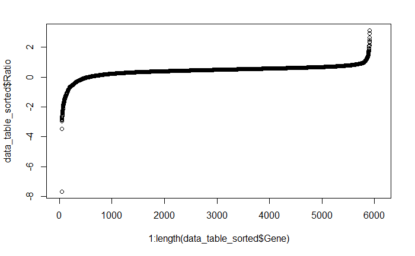

```r
plot(1:length(data_table_sorted$Gene),data_table_sorted$Ratio)
```